# 2017218069_정경준_Boston

2022-12-16

## Boston 데이터 회귀 분석

#### 이번 분석에 사용한 회귀 분석이란 연속형과 수치형반응 변수를 분석하는 방법입니다.

### 1. 함수 작성 및 환경 준비

```r
rmse <- function(yi, yhat_i){
  sqrt(mean((yi - yhat_i)^2))
}
```

> 가장 처음으로 RMSE함수를 다음과 같이 정의합니다.
> RMSE(Root MEan Squared Error): > 회귀분석에서의 오차
> $$RMSE = \sqrt{\frac{1}{n} \sum_{i=1}^n
> (y_i-\hat{y}_i)^2}$$
> RMSE는 예측오차로 값이 작을수록 더 정확한 모형입니다.

다음으로 다음과 같이 필요한 패키지들을 불러옵니다.

```r
library(tidyverse)
library(MASS) #로버스트 선형회귀를 위한 패키지
library(glmnet) #라쏘, 능형, 일래스틱넷 모형을 위한 패키지
library(randomForest) #탠덤 포레스트 모형을 위한 패키지
library(gbm) #부스팅을 위한 패키지
library(rpart) #나무모형을 위한 패키지
library(boot) #유의미한 변수선택을 위한 패키지
library(data.table) #데이터 테이블 형을 위한 패키지
library(ROCR) #ROC 곡선을 위한 패키지
library(ggplot2) #데이터 시각화를 위한 패키지
library(dplyr) #데이터 가공 문법을 위한 패키지
library(gridExtra) #그래프를 격자 형태로 보기 위한 패키지
```

### 2. Boston 데이터 읽어오기

```r
housing <- read.table("https://archive.ics.uci.edu/ml/machine-learning-databases/housing/housing.data", strip.white = T)
data <- tbl_df(housing)
names(data) <- c('crim', 'zn','indus','chas','nox','rm','age','dis','rad','tax','ptratio','b','lstat','medv')
glimpse(data) #반응변수는 medv: 주택가격
```

```
## Rows: 506
## Columns: 14
## $ crim    <dbl> 0.00632, 0.02731, 0.02729, 0.03237, 0.06905, 0.02985, 0.08829,…
## $ zn      <dbl> 18.0, 0.0, 0.0, 0.0, 0.0, 0.0, 12.5, 12.5, 12.5, 12.5, 12.5, 1…
## $ indus   <dbl> 2.31, 7.07, 7.07, 2.18, 2.18, 2.18, 7.87, 7.87, 7.87, 7.87, 7.…
## $ chas    <int> 0, 0, 0, 0, 0, 0, 0, 0, 0, 0, 0, 0, 0, 0, 0, 0, 0, 0, 0, 0, 0,…
## $ nox     <dbl> 0.538, 0.469, 0.469, 0.458, 0.458, 0.458, 0.524, 0.524, 0.524,…
## $ rm      <dbl> 6.575, 6.421, 7.185, 6.998, 7.147, 6.430, 6.012, 6.172, 5.631,…
## $ age     <dbl> 65.2, 78.9, 61.1, 45.8, 54.2, 58.7, 66.6, 96.1, 100.0, 85.9, 9…
## $ dis     <dbl> 4.0900, 4.9671, 4.9671, 6.0622, 6.0622, 6.0622, 5.5605, 5.9505…
## $ rad     <int> 1, 2, 2, 3, 3, 3, 5, 5, 5, 5, 5, 5, 5, 4, 4, 4, 4, 4, 4, 4, 4,…
## $ tax     <dbl> 296, 242, 242, 222, 222, 222, 311, 311, 311, 311, 311, 311, 31…
## $ ptratio <dbl> 15.3, 17.8, 17.8, 18.7, 18.7, 18.7, 15.2, 15.2, 15.2, 15.2, 15…
## $ b       <dbl> 396.90, 396.90, 392.83, 394.63, 396.90, 394.12, 395.60, 396.90…
## $ lstat   <dbl> 4.98, 9.14, 4.03, 2.94, 5.33, 5.21, 12.43, 19.15, 29.93, 17.10…
## $ medv    <dbl> 24.0, 21.6, 34.7, 33.4, 36.2, 28.7, 22.9, 27.1, 16.5, 18.9, 15…
```

### 3. 시각화

```r
panel.cor <- function(x, y, digits = 2, prefix = "", cex.cor, ...){
  usr <- par("usr"); on.exit(par(usr))
  par(usr = c(0, 1, 0, 1))
  r <- abs(cor(x, y))
  txt <- format(c(r, 0.123456789), digits = digits)[1]
  txt <- paste0(prefix, txt)
  if(missing(cex.cor)) cex.cor <- 0.8/strwidth(txt)
  text(0.5, 0.5, txt, cex = cex.cor * r)
}
```

> 시각화를 위한 pairs()함수를 위한 panel.cor함수를 다음과 같이 정의합니다.

pairs()함수로 14개의 변수들 간의 산점도입니다.

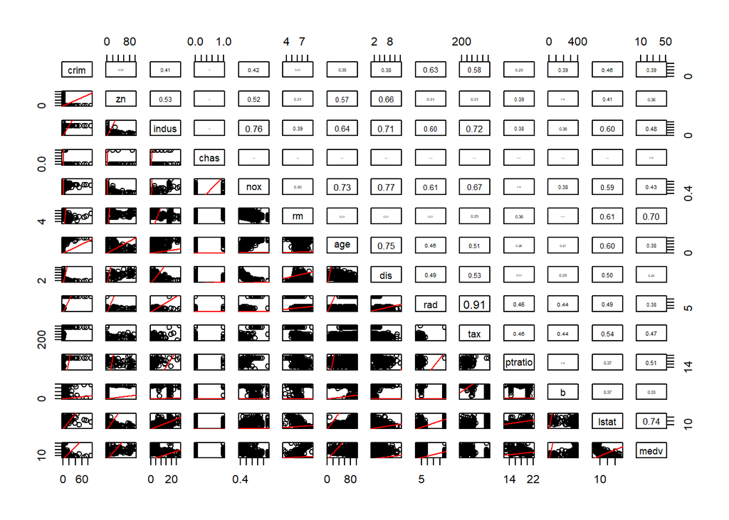

```r
pairs(data %>% dplyr::sample_n(min(1000, nrow(data))),
      lower.panel=function(x,y){ points(x,y); abline(0, 1, col='red')},
      upper.panel = panel.cor)
```

### 4. 훈련,검증,테스트 세트의 구분

데이터 세트를 훈련,검증,테스트 각각 60:20:20으로 나눕니다

```r
set.seed(1606)
n <- nrow(data)
idx <- 1:n
```

> 재현 가능성을 위한 관측치 개수 n을 정의를 하고 index는 1부터 n까지로 할당합니다.

```r
training_idx <- sample(idx, n * .60)
idx <- setdiff(idx, training_idx)
validate_idx <- sample(idx, n * .20)
test_idx <- setdiff(idx, validate_idx)
```

위의 과정을 진행을 한 후에 각각의 훈련,검증,테스트용 데이터세트로 정의를 합니다.

```r
training <- data[training_idx,]
validation <- data[validate_idx,]
test <- data[test_idx,]
```

### 5. 선형 회귀 모델

```r
data_lm_full <- lm(medv ~ ., data=training)
summary(data_lm_full)
```

```
##
## Call:
## lm(formula = medv ~ ., data = training)
##
## Residuals:
##      Min       1Q   Median       3Q      Max
## -10.7779  -2.7917  -0.6996   1.8940  25.6443
##
## Coefficients:
##               Estimate Std. Error t value Pr(>|t|)
## (Intercept)  30.597370   6.472844   4.727 3.56e-06 ***
## crim         -0.105146   0.035900  -2.929 0.003673 **
## zn            0.043363   0.017482   2.480 0.013691 *
## indus        -0.055383   0.076866  -0.721 0.471792
## chas          2.880243   1.083849   2.657 0.008312 **
## nox         -17.412105   4.769490  -3.651 0.000310 ***
## rm            4.524753   0.551838   8.199 7.97e-15 ***
## age          -0.010986   0.017129  -0.641 0.521796
## dis          -1.607727   0.253495  -6.342 8.70e-10 ***
## rad           0.304656   0.084490   3.606 0.000366 ***
## tax          -0.012165   0.004915  -2.475 0.013892 *
## ptratio      -0.801398   0.163204  -4.910 1.52e-06 ***
## b             0.007910   0.003465   2.283 0.023148 *
## lstat        -0.456135   0.068098  -6.698 1.10e-10 ***
## ---
## Signif. codes:  0 '***' 0.001 '**' 0.01 '*' 0.05 '.' 0.1 ' ' 1
##
## Residual standard error: 4.632 on 289 degrees of freedom
## Multiple R-squared:  0.7549, Adjusted R-squared:  0.7439
## F-statistic: 68.47 on 13 and 289 DF,  p-value: < 2.2e-16
```

> 선형회귀 모델에 적합한 lm함수를 사용합니다.  
> lm(반응변수 ~ 설명변수1 + 설명변수2 + … , data=훈련용 데이터 세트)함수를 사용하였습니다.  
> medv ~ 뒤에 .표시는 모든 설명 변수를 의미합니다. 그리고 summary함수를 사용하여 선형회귀 모형 적합 결과를 확인합니다.  
> 결정 계수 R-squared 값이 1에 가까워야 좋은 모형이지만 0.7549로 그다지 좋지 않은 값을 확인합니다.

선형회귀 모형에서 설명변수를 선택  
위의 선형 회귀 모형에서는 모든 설명 변수로 적합을 했는데 이번에는 변수를 조금 수정해서 적합을 해봅니다.  
조금 더 복잡한 모든 이차상호작용을 고려를 하여 다시 모형을 만들었습니다.

```r
data_lm_full2 = lm(medv ~ .^2, data = training)
summary(data_lm_full2)
```

```
##
## Call:
## lm(formula = medv ~ .^2, data = training)
##
## Residuals:
##     Min      1Q  Median      3Q     Max
## -7.1961 -1.3908 -0.0927  1.2392 19.4237
##
## Coefficients:
##                 Estimate Std. Error t value Pr(>|t|)
## (Intercept)   -4.423e+01  1.108e+02  -0.399 0.690137
## crim          -7.479e+00  9.254e+00  -0.808 0.419917
## zn             2.521e-01  8.310e-01   0.303 0.761890
## indus         -1.979e+00  2.653e+00  -0.746 0.456470
## chas           6.122e+01  3.434e+01   1.783 0.076051 .
## nox           -1.298e+02  1.166e+02  -1.113 0.266925
## rm             2.079e+01  1.053e+01   1.974 0.049679 *
## age            1.579e+00  4.524e-01   3.491 0.000586 ***
## dis           -5.525e+00  7.496e+00  -0.737 0.461907
## rad            7.165e-01  3.798e+00   0.189 0.850557
## tax            4.570e-02  2.422e-01   0.189 0.850528
## ptratio       -3.733e+00  4.303e+00  -0.868 0.386614
## b              7.959e-03  1.085e-01   0.073 0.941592
## lstat          2.932e+00  1.373e+00   2.136 0.033841 *
## crim:zn        3.303e-01  2.746e-01   1.203 0.230428
## crim:indus     3.126e-01  8.534e-01   0.366 0.714465
## crim:chas      1.224e+00  7.856e-01   1.558 0.120781
## crim:nox      -1.135e+00  1.369e+00  -0.829 0.408029
## crim:rm        8.026e-02  7.128e-02   1.126 0.261427
## crim:age      -6.850e-03  5.396e-03  -1.270 0.205655
## crim:dis      -2.207e-01  1.484e-01  -1.487 0.138598
## crim:rad       1.475e-02  1.127e+00   0.013 0.989575
## crim:tax      -1.133e-02  8.348e-02  -0.136 0.892145
## crim:ptratio   4.856e-01  5.081e-01   0.956 0.340301
## crim:b        -3.369e-04  2.280e-04  -1.478 0.140920
## crim:lstat     2.128e-02  1.004e-02   2.121 0.035130 *
## zn:indus       2.954e-03  8.133e-03   0.363 0.716834
## zn:chas       -7.697e-02  1.114e-01  -0.691 0.490227
## zn:nox         5.064e-01  7.935e-01   0.638 0.524007
## zn:rm          5.976e-04  3.851e-02   0.016 0.987633
```

[output cut: 53 more lines]

```
## rad:ptratio   -3.007e-02  1.199e-01  -0.251 0.802197
## rad:b         -3.211e-03  4.480e-03  -0.717 0.474357
## rad:lstat     -2.586e-02  3.302e-02  -0.783 0.434527
## tax:ptratio    7.234e-03  3.538e-03   2.045 0.042094 *
## tax:b          2.123e-04  3.538e-04   0.600 0.549227
## tax:lstat     -1.024e-03  2.358e-03  -0.434 0.664748
## ptratio:b      4.090e-03  4.593e-03   0.890 0.374263
## ptratio:lstat -3.061e-02  4.952e-02  -0.618 0.537109
## b:lstat       -8.469e-04  5.813e-04  -1.457 0.146594
## ---
## Signif. codes:  0 '***' 0.001 '**' 0.01 '*' 0.05 '.' 0.1 ' ' 1
##
## Residual standard error: 2.943 on 211 degrees of freedom
## Multiple R-squared:  0.9278, Adjusted R-squared:  0.8966
## F-statistic: 29.79 on 91 and 211 DF,  p-value: < 2.2e-16
```

> 전에 모형과는 다르게 결정계수 R-squared 값0.9278 / 수정된 결정계수 R-squared : 0.8966으로 모형이 좋아진 것을 확인할 수 있습니다.

```r
length(coef(data_lm_full2))
```

```
## [1] 92
```

> 그러나 모수의 개수가 92개로 많이 복잡해졌습니다. 따라서 92개 중 가장 중요한 모수를 선택하기로 했습니다.

stepAIC(선형회귀 모형, scope=list(upper=~ ,lower=~ 1))  
중요한 변수를 자동으로 선택을 해주는 함수입니다.

```r
data_step = stepAIC(data_lm_full, scope = list(upper = ~ .^2, lower = ~1))
```

> data_step은 가장 중요한 모수들만 모아 적합한 선형 회귀 모형이 됩니다.

data_step 모형의 summary

```r
summary(data_step)
```

```
##
## Call:
## lm(formula = medv ~ crim + indus + chas + nox + rm + age + dis +
##     rad + tax + ptratio + b + lstat + rm:lstat + dis:rad + crim:chas +
##     rm:rad + b:lstat + nox:rad + chas:nox + indus:chas + age:b +
##     nox:age + nox:dis + indus:tax + tax:lstat + rm:tax + rm:age +
##     nox:rm + chas:dis + age:lstat + nox:b + chas:lstat + dis:lstat,
##     data = training)
##
## Residuals:
##     Min      1Q  Median      3Q     Max
## -9.2547 -1.5678 -0.1295  1.1478 20.3976
##
## Coefficients:
##               Estimate Std. Error t value Pr(>|t|)
## (Intercept) -1.249e+02  1.895e+01  -6.590 2.31e-10 ***
## crim        -1.497e-01  2.482e-02  -6.032 5.34e-09 ***
## indus       -3.409e-01  1.205e-01  -2.830 0.005006 **
## chas         2.765e+01  7.807e+00   3.542 0.000468 ***
## nox         -2.576e+01  3.083e+01  -0.836 0.404133
## rm           1.574e+01  2.015e+00   7.812 1.27e-13 ***
## age          1.038e+00  2.030e-01   5.112 6.06e-07 ***
## dis          3.029e+00  1.080e+00   2.805 0.005393 **
## rad          3.126e-01  6.889e-01   0.454 0.650378
## tax          1.318e-01  3.739e-02   3.525 0.000497 ***
## ptratio     -5.461e-01  1.110e-01  -4.922 1.50e-06 ***
## b            9.153e-02  2.476e-02   3.697 0.000265 ***
## lstat        3.357e+00  4.009e-01   8.375 3.08e-15 ***
## rm:lstat    -3.003e-01  5.072e-02  -5.921 9.72e-09 ***
## dis:rad     -1.390e-01  3.372e-02  -4.122 5.01e-05 ***
## crim:chas    1.293e+00  3.739e-01   3.458 0.000632 ***
## rm:rad       1.593e-01  1.007e-01   1.583 0.114688
## b:lstat     -9.307e-04  3.809e-04  -2.443 0.015199 *
## nox:rad     -9.467e-01  3.751e-01  -2.524 0.012191 *
## chas:nox    -4.395e+01  1.133e+01  -3.879 0.000132 ***
## indus:chas   6.932e-01  3.005e-01   2.306 0.021850 *
## age:b       -1.100e-03  2.711e-04  -4.058 6.49e-05 ***
## nox:age     -4.056e-01  1.574e-01  -2.578 0.010478 *
## nox:dis     -6.321e+00  2.628e+00  -2.406 0.016820 *
## indus:tax    9.708e-04  3.134e-04   3.098 0.002157 **
## tax:lstat   -2.631e-03  3.570e-04  -7.368 2.13e-12 ***
## rm:tax      -2.083e-02  5.568e-03  -3.741 0.000224 ***
## rm:age      -6.977e-02  1.997e-02  -3.493 0.000559 ***
## nox:rm       9.829e+00  4.198e+00   2.341 0.019938 *
## chas:dis    -2.657e+00  1.286e+00  -2.066 0.039739 *
## age:lstat   -3.707e-03  1.978e-03  -1.875 0.061915 .
## nox:b        4.108e-02  2.753e-02   1.492 0.136785
## chas:lstat  -2.482e-01  1.455e-01  -1.706 0.089127 .
## dis:lstat   -4.318e-02  3.017e-02  -1.431 0.153464
## ---
## Signif. codes:  0 '***' 0.001 '**' 0.01 '*' 0.05 '.' 0.1 ' ' 1
##
## Residual standard error: 2.898 on 269 degrees of freedom
## Multiple R-squared:  0.9107, Adjusted R-squared:  0.8998
## F-statistic: 83.17 on 33 and 269 DF,  p-value: < 2.2e-16
```

> 결정계수 R-squared: 0.9107 / 수정된 결정계수 R-squared: 0.8998로 모형은 좋은 모형임을 나타냅니다

```r
length(coef(data_step))
```

```
## [1] 34
```

> 모수도 92개에서 34개로 줄어들어 덜 복잡한 모형이 생긴걸 확인을 할 수 있습니다.

### 선형 회귀 모형의 평가

```r
y_obs <- validation$medv #반응 변수
#3가지 모형, 각각 평가
yhat_lm <- predict(data_lm_full, newdata=validation)
yhat_lm_2 <- predict(data_lm_full2, newdata=validation)
yhat_step <- predict(data_step, newdata=validation)
```

> 검증용 데이터 세트를 이용하여 모형의 예측능력을 계산합니다.  
> predict(lm(), newdata= 검증세트) 함수를 사용하였으며,  
> 그 후 rmse(검증 세트의 반응 변수, predict() ) 함수를 이용하여 RMSE(예측오차)를 구하였습니다.

```r
rmse(y_obs, yhat_lm)
```

```
## [1] 4.014455
```

```r
rmse(y_obs, yhat_lm_2)
```

```
## [1] 3.945042
```

```r
rmse(y_obs, yhat_step)
```

```
## [1] 3.268262
```

> RMSE(예측오차)가 작을수록 예측 능력이 좋은 모형인데  
> 세 모형중 stepAIC 함수를 이용한 모형(data_step)이 RMSE: 3.268262로 예측 능력이 가장 높은것을 확인을 할 수 있습니다.

### 6. 라쏘 모형 적합

```r
xx <- model.matrix(medv ~ .^2-1, data)
x <- xx[training_idx, ]
y <- training$medv
```

> model.matrix()를 이용하여 모형 행렬을 생성한 후, cv.glmnet()를 사용하였습니다.  
> cv.lgmnet(모형행렬 중 훈련세트, 훈련 세트의 반응 변수)중 ^2-1로 한 이유는 모든 이차상호작용을 포함하고자 함입니다.

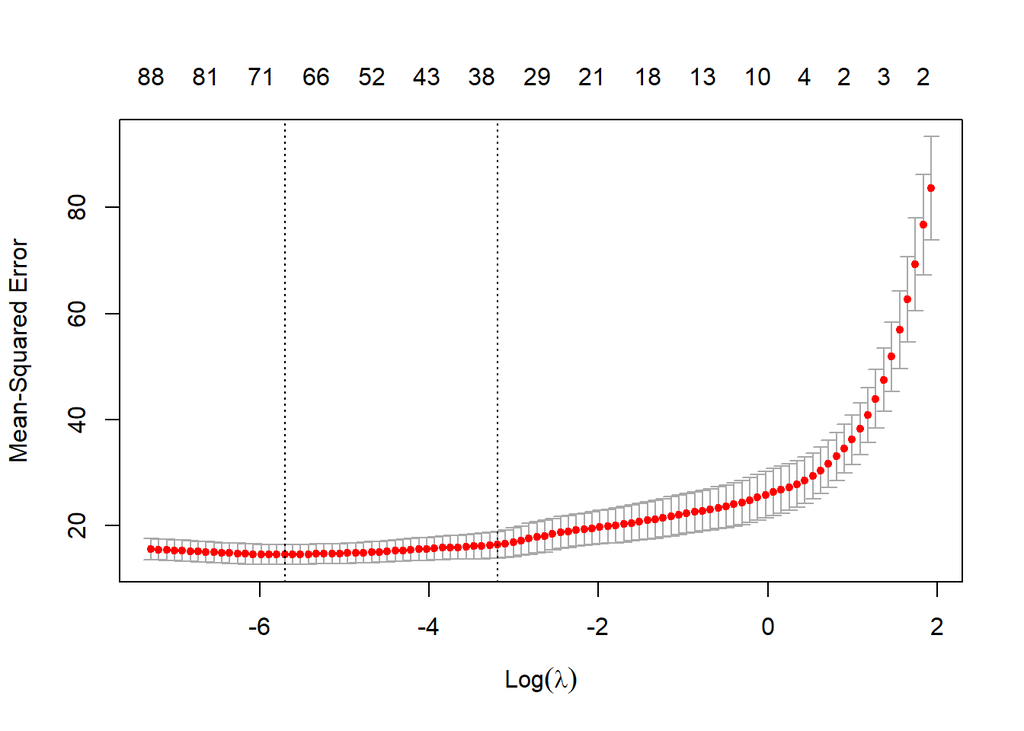

```r
data_cvfit <- cv.glmnet(x, y)
plot(data_cvfit)
```

> 왼쪽 점선: lambda.min 오른쪽 점선: lambda.1se

```r
coef(data_cvfit, s=c("lambda.1se"))
```

[output not shown]

```r
log(data_cvfit$lambda.1se)
```

```
## [1] -3.190865
```

```r
length(which(coef(data_cvfit, s=c("lambda.1se")) !=0))-1
```

```
## [1] 35
```

> lambda.1se 방법에서 로그 lambda 값을 출력을 합니다.  
> 그 다음코드로 선택된 변수가 35개인 것을 확인을 할 수 있으며, -1을 해주는 이유는 절편향(intercept)을 제외하기 위하며 -1을 해주었습니다.

```r
coef(data_cvfit, s = c("lambda.min"))
```

[output not shown]

```r
log(data_cvfit$lambda.min)
```

```
## [1] -5.702776
```

```r
length(which(coef(data_cvfit, s=c("lambda.min")) !=0))-1
```

```
## [1] 71
```

> lambda.min 방법에서 로그 lambda 값을 출력을 하고,  
> 선택된 변수가 71개임을 확인 하였습니다.

### 예측해보기

```r
predict(data_cvfit, s="lambda.min", newx = x[1:5, ])
```

```
##     lambda.min
## 215  22.639951
## 503  19.836698
## 236  24.096534
## 439   3.121172
## 447  15.077876
```

> 훈련용 데이터에서 x의 1~5행의 관측치를 통해서 예측을 하였습니다.

### 라쏘 모형평가

```r
y_obs <- validation$medv
yhat_glmnet <- predict(data_cvfit, s="lambda.min", newx=xx[validate_idx,])
rmse(y_obs, yhat_glmnet)
```

```
## [1] 3.055207
```

> predict(cv.glmnet(), s=“lambda.min”, newx=검증세트) 함수를 사용하였습니다.  
> rmse(검증세트의 반응 변수, predict()) 함수로 예측오차를 구하였으며  
> RMSE 예측 오차값이 3.055207임을 확인하였습니다.

### 7. 나무 모형

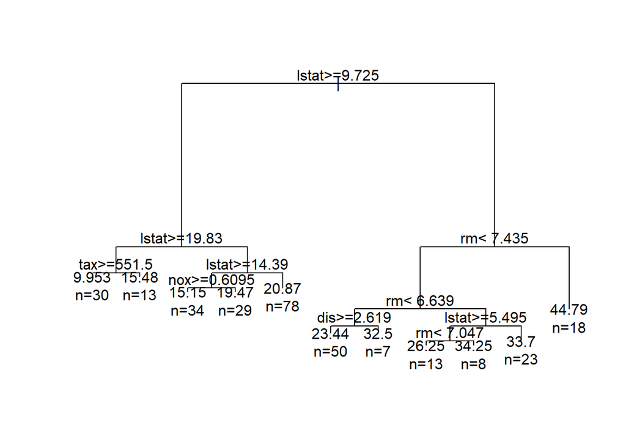

```r
data_tr <- rpart(medv ~ ., data = training)
par(mfrow = c(1,1), xpd = NA)
plot(data_tr)
text(data_tr, use.n = TRUE)
```

> 나무 모형 적합으로 rpart(반응 변수~., data=훈련용 데이터 세트)를 사용하였습니다.

### 간단히 예측해보기

```r
predict(data_tr,newdata = data[1:5, ])
```

```
##        1        2        3        4        5
## 23.43800 23.43800 33.69565 33.69565 33.69565
```

### 나무 모형 모형평가

```r
y_obs <- validation$medv
yhat_tr <- predict(data_tr, validation)
rmse(y_obs, yhat_tr)
```

```
## [1] 3.94209
```

### 랜덤 포레스트

```r
set.seed(1607)
data_rf <- randomForest(medv ~ ., training)
```

> randomForest(반응변수 ~.,data= 훈련용 데이터 세트)함수를 사용하여 랜텀 포레스트 모형에 적합하였습니다.

```r
data_rf
```

```
##
## Call:
##  randomForest(formula = medv ~ ., data = training)
##                Type of random forest: regression
##                      Number of trees: 500
## No. of variables tried at each split: 4
##
##           Mean of squared residuals: 13.70847
##                     % Var explained: 83.58
```

> data_rf 확인

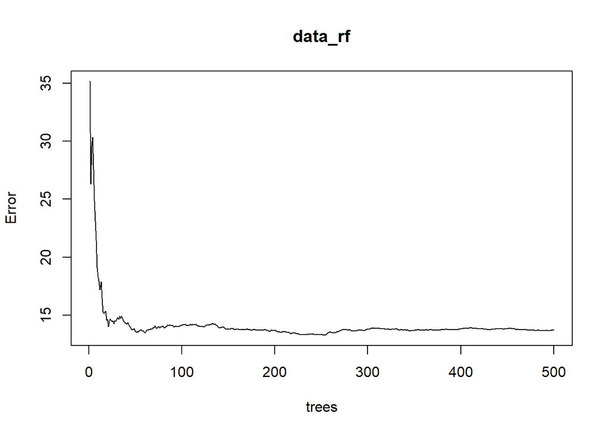

```r
plot(data_rf) #오차율 감소
```

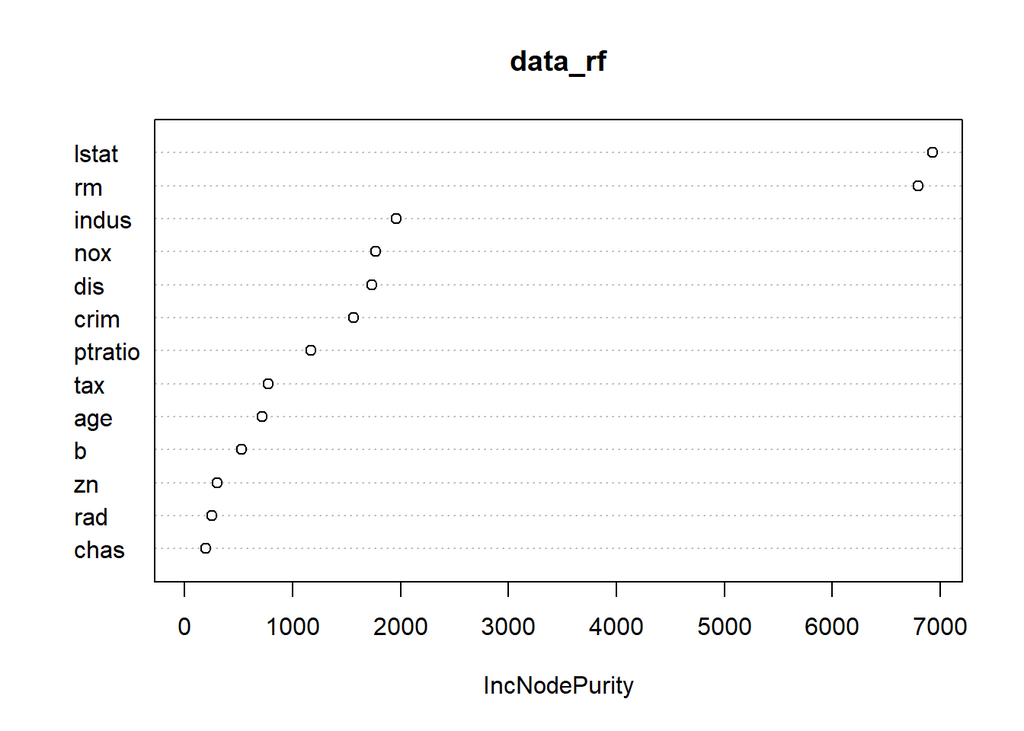

```r
varImpPlot(data_rf) #변수 중요도
```

> 나무 개수가 50개 정도에서 더 이상 MSE가 감소하지 않는 것을 알 수 있습니다.  
> 변수의 중요도 plot은 가장 중요한 변수부터 위에서 아래로 정렬되어 있습니다.  
> (여기서 lstat와 rm변수가 중요한 변수입니다.)

### 간단히 예측해보기

```r
predict(data_rf, newdata=data[1:5,])
```

```
##        1        2        3        4        5
## 25.19063 22.44216 33.97866 33.82451 34.83382
```

### 랜덤 포레스트 모형 평가

```r
y_obs <- validation$medv
yhat_rf <- predict(data_rf, newdata=validation)
rmse(y_obs, yhat_rf)
```

```
## [1] 2.536608
```

> 지금까지의 적합한 모형 중 RMSE: 2.536608로 가장 낮으며 이는 예측 능력이 가장 좋다는 것을 의미합니다.

### 부스팅

```r
set.seed(1607)

data_gbm <- gbm(medv ~ ., data=training,
                n.trees=30000, cv.folds=3, verbose = TRUE)
```

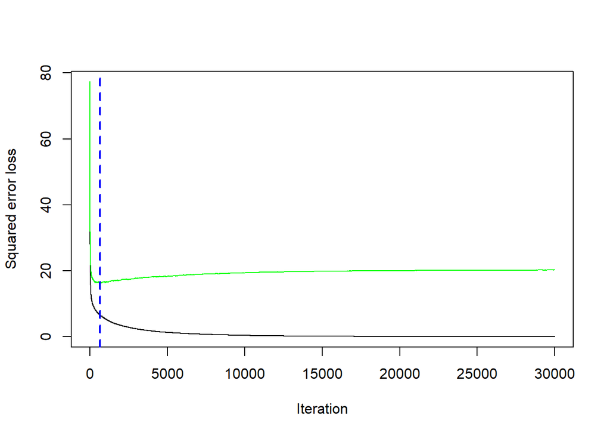

```
## [1] 663
```

```r
(best_iter = gbm.perf(data_gbm, method="cv"))
```

> 부스팅 모형 적합 & 최적 반복수 : 663을 확인하였습니다.

### 부스팅 모형 평가

```r
y_obs<-validation$medv
yhat_gbm <- predict(data_gbm, n.trees=best_iter, newdata=validation)
rmse(y_obs, yhat_gbm)
```

```
## [1] 2.863752
```

### 최종 모형 선택과 테스트 세트 오차 계산

선형 회귀, 라쏘, 나무 모형, 랜덤 포레스트, 부스팅까지 총 5개의 모형의 RMSE값을 비교합니다.

```r
data.frame(
  method=c('lm','glmnet','tr','rf','gbm'),
  rmse=c(rmse(y_obs, yhat_step),
           rmse(y_obs, yhat_glmnet),
           rmse(y_obs, yhat_tr),
           rmse(y_obs, yhat_rf),
           rmse(y_obs, yhat_gbm)))
```

```
##   method     rmse
## 1     lm 3.268262
## 2 glmnet 3.055207
## 3     tr 3.942090
## 4     rf 2.536608
## 5    gbm 2.863752
```

> RMSE값이 가장 낮은 것부터 순서대로  
> 랜덤 포레스트 < 부스팅 < 라쏘 < 선형 회귀 < 나무모형  
> 순으로 확인을 할 수 있습니다.

```r
rmse(test$medv, predict(data_rf, newdata = test))
```

```
## [1] 3.617272
```

> RF의 테스트 데이터 세트에서의 RMSE값은 다음과 같습니다.

### 회귀 분석의 오차 시각화(병렬 상자 그림)

여러 회귀 방법의 오차를 비교하는 시각화 방법 중 하나로 예측 분포를 병렬상자 그림으로 보여주는 것 입니다.

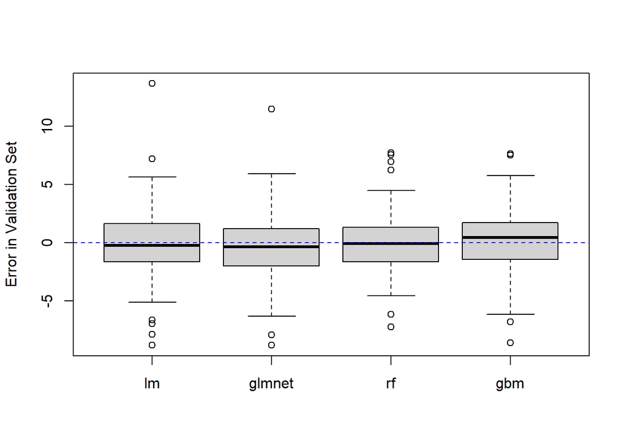

```r
boxplot(list(lm = y_obs-yhat_step,

             glmnet = y_obs-yhat_glmnet,

             rf = y_obs-yhat_rf,

             gbm = y_obs-yhat_gbm), ylab="Error in Validation Set")

abline(h=0, lty=2, col='blue')
```

또한 모형들 간의 예측값들 끼리 산점도 행렬을 그려보면 다음과 같습니다.

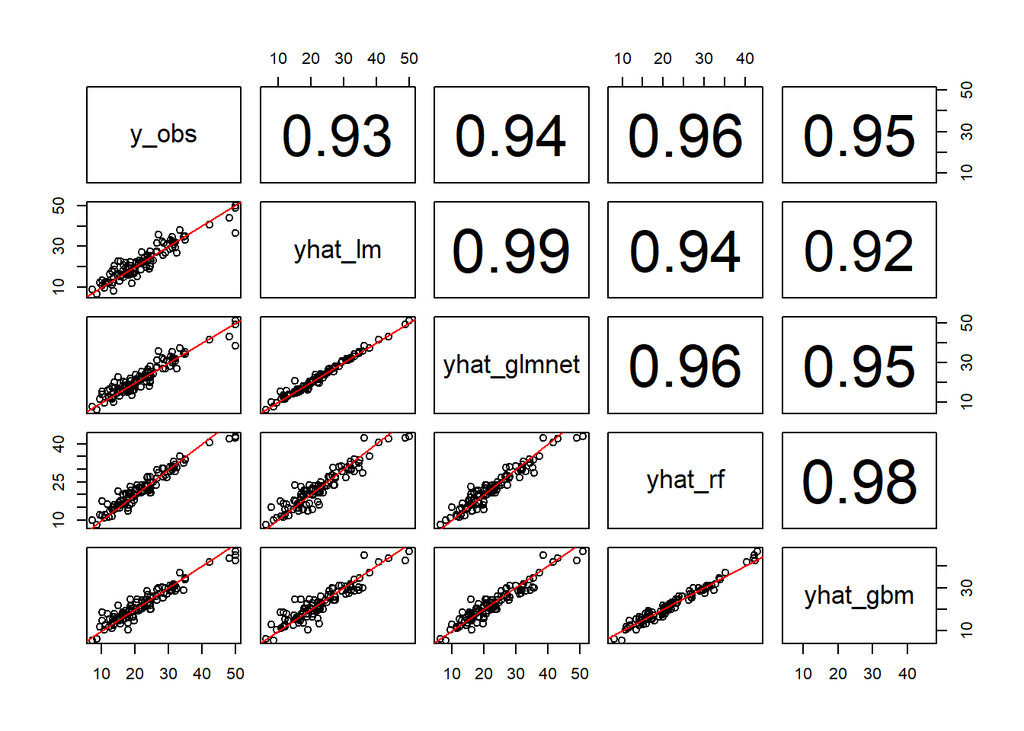

```r
pairs(data.frame(y_obs=y_obs,

                 yhat_lm=yhat_step,

                 yhat_glmnet=c(yhat_glmnet),

                 yhat_rf=yhat_rf,

                 yhat_gbm=yhat_gbm),

      lower.panel=function(x,y){ points(x,y); abline(0, 1, col='red')},

      upper.panel = panel.cor)
```

> 그림에서 알 수 있듯 stepwise 변수 선택 모형과 glmnet 예측값끼리는 상관 계수가 높고, RF와 gbm값 끼리도 상관계수가 높은 것으로 보입니다.  
> 관측값과 상관계수가 가장 높은 방법은 RF입니다.